# Risk Factor Analysis

## Outcome Variable

**Outcome Variable:** pers_wast

## Predictor Variables

**Intervention Variable:** nrooms

**Adjustment Set:**

unadjusted

## Stratifying Variables

The analysis was stratified on these variable(s):

- agecat
- studyid
- country

## Data Summary

| agecat | studyid | country | nrooms | pers_wast | n_cell | n |
| --- | --- | --- | --- | --- | --- | --- |
| 0-24 months | CMC-V-BCS-2002 | INDIA | 4+ | 0 | 14 | 373 |
| 0-24 months | CMC-V-BCS-2002 | INDIA | 4+ | 1 | 0 | 373 |
| 0-24 months | CMC-V-BCS-2002 | INDIA | 1 | 0 | 189 | 373 |
| 0-24 months | CMC-V-BCS-2002 | INDIA | 1 | 1 | 13 | 373 |
| 0-24 months | CMC-V-BCS-2002 | INDIA | 2 | 0 | 97 | 373 |
| 0-24 months | CMC-V-BCS-2002 | INDIA | 2 | 1 | 9 | 373 |
| 0-24 months | CMC-V-BCS-2002 | INDIA | 3 | 0 | 50 | 373 |
| 0-24 months | CMC-V-BCS-2002 | INDIA | 3 | 1 | 1 | 373 |
| 0-24 months | COHORTS | INDIA | 4+ | 0 | 75 | 4119 |
| 0-24 months | COHORTS | INDIA | 4+ | 1 | 2 | 4119 |
| 0-24 months | COHORTS | INDIA | 1 | 0 | 2328 | 4119 |
| 0-24 months | COHORTS | INDIA | 1 | 1 | 310 | 4119 |
| 0-24 months | COHORTS | INDIA | 2 | 0 | 1162 | 4119 |
| 0-24 months | COHORTS | INDIA | 2 | 1 | 93 | 4119 |
| 0-24 months | COHORTS | INDIA | 3 | 0 | 142 | 4119 |
| 0-24 months | COHORTS | INDIA | 3 | 1 | 7 | 4119 |
| 0-24 months | CONTENT | PERU | 4+ | 0 | 78 | 215 |
| 0-24 months | CONTENT | PERU | 4+ | 1 | 0 | 215 |
| 0-24 months | CONTENT | PERU | 1 | 0 | 44 | 215 |
| 0-24 months | CONTENT | PERU | 1 | 1 | 0 | 215 |
| 0-24 months | CONTENT | PERU | 2 | 0 | 54 | 215 |
| 0-24 months | CONTENT | PERU | 2 | 1 | 0 | 215 |
| 0-24 months | CONTENT | PERU | 3 | 0 | 39 | 215 |
| 0-24 months | CONTENT | PERU | 3 | 1 | 0 | 215 |
| 0-24 months | GMS-Nepal | NEPAL | 4+ | 0 | 246 | 597 |
| 0-24 months | GMS-Nepal | NEPAL | 4+ | 1 | 35 | 597 |
| 0-24 months | GMS-Nepal | NEPAL | 1 | 0 | 34 | 597 |
| 0-24 months | GMS-Nepal | NEPAL | 1 | 1 | 6 | 597 |
| 0-24 months | GMS-Nepal | NEPAL | 2 | 0 | 108 | 597 |
| 0-24 months | GMS-Nepal | NEPAL | 2 | 1 | 20 | 597 |

[output cut: 338 more lines]

The following strata were considered:

- agecat: 0-24 months, studyid: CMC-V-BCS-2002, country: INDIA
- agecat: 0-24 months, studyid: COHORTS, country: INDIA
- agecat: 0-24 months, studyid: CONTENT, country: PERU
- agecat: 0-24 months, studyid: GMS-Nepal, country: NEPAL
- agecat: 0-24 months, studyid: IRC, country: INDIA
- agecat: 0-24 months, studyid: JiVitA-3, country: BANGLADESH
- agecat: 0-24 months, studyid: JiVitA-4, country: BANGLADESH
- agecat: 0-24 months, studyid: MAL-ED, country: BANGLADESH
- agecat: 0-24 months, studyid: MAL-ED, country: BRAZIL
- agecat: 0-24 months, studyid: MAL-ED, country: INDIA
- agecat: 0-24 months, studyid: MAL-ED, country: NEPAL
- agecat: 0-24 months, studyid: MAL-ED, country: PERU
- agecat: 0-24 months, studyid: MAL-ED, country: SOUTH AFRICA
- agecat: 0-24 months, studyid: MAL-ED, country: TANZANIA, UNITED REPUBLIC OF
- agecat: 0-24 months, studyid: NIH-Crypto, country: BANGLADESH
- agecat: 0-24 months, studyid: PROVIDE, country: BANGLADESH
- agecat: 0-6 months, studyid: CMC-V-BCS-2002, country: INDIA
- agecat: 0-6 months, studyid: CONTENT, country: PERU
- agecat: 0-6 months, studyid: GMS-Nepal, country: NEPAL
- agecat: 0-6 months, studyid: IRC, country: INDIA
- agecat: 0-6 months, studyid: JiVitA-3, country: BANGLADESH
- agecat: 0-6 months, studyid: MAL-ED, country: BANGLADESH
- agecat: 0-6 months, studyid: MAL-ED, country: BRAZIL
- agecat: 0-6 months, studyid: MAL-ED, country: INDIA
- agecat: 0-6 months, studyid: MAL-ED, country: NEPAL
- agecat: 0-6 months, studyid: MAL-ED, country: PERU
- agecat: 0-6 months, studyid: MAL-ED, country: SOUTH AFRICA
- agecat: 0-6 months, studyid: MAL-ED, country: TANZANIA, UNITED REPUBLIC OF
- agecat: 0-6 months, studyid: NIH-Crypto, country: BANGLADESH
- agecat: 0-6 months, studyid: PROVIDE, country: BANGLADESH
- agecat: 6-24 months, studyid: CMC-V-BCS-2002, country: INDIA
- agecat: 6-24 months, studyid: COHORTS, country: INDIA
- agecat: 6-24 months, studyid: CONTENT, country: PERU
- agecat: 6-24 months, studyid: GMS-Nepal, country: NEPAL
- agecat: 6-24 months, studyid: IRC, country: INDIA
- agecat: 6-24 months, studyid: JiVitA-3, country: BANGLADESH
- agecat: 6-24 months, studyid: JiVitA-4, country: BANGLADESH
- agecat: 6-24 months, studyid: MAL-ED, country: BANGLADESH
- agecat: 6-24 months, studyid: MAL-ED, country: BRAZIL
- agecat: 6-24 months, studyid: MAL-ED, country: INDIA
- agecat: 6-24 months, studyid: MAL-ED, country: NEPAL
- agecat: 6-24 months, studyid: MAL-ED, country: PERU
- agecat: 6-24 months, studyid: MAL-ED, country: SOUTH AFRICA
- agecat: 6-24 months, studyid: MAL-ED, country: TANZANIA, UNITED REPUBLIC OF
- agecat: 6-24 months, studyid: NIH-Crypto, country: BANGLADESH
- agecat: 6-24 months, studyid: PROVIDE, country: BANGLADESH

### Dropped Strata

Some strata were dropped due to rare outcomes:

- agecat: 0-24 months, studyid: CMC-V-BCS-2002, country: INDIA
- agecat: 0-24 months, studyid: COHORTS, country: INDIA
- agecat: 0-24 months, studyid: CONTENT, country: PERU
- agecat: 0-24 months, studyid: IRC, country: INDIA
- agecat: 0-24 months, studyid: MAL-ED, country: BANGLADESH
- agecat: 0-24 months, studyid: MAL-ED, country: BRAZIL
- agecat: 0-24 months, studyid: MAL-ED, country: INDIA
- agecat: 0-24 months, studyid: MAL-ED, country: NEPAL
- agecat: 0-24 months, studyid: MAL-ED, country: PERU
- agecat: 0-24 months, studyid: MAL-ED, country: SOUTH AFRICA
- agecat: 0-24 months, studyid: MAL-ED, country: TANZANIA, UNITED REPUBLIC OF
- agecat: 0-24 months, studyid: NIH-Crypto, country: BANGLADESH
- agecat: 0-24 months, studyid: PROVIDE, country: BANGLADESH
- agecat: 0-6 months, studyid: CMC-V-BCS-2002, country: INDIA
- agecat: 0-6 months, studyid: CONTENT, country: PERU
- agecat: 0-6 months, studyid: IRC, country: INDIA
- agecat: 0-6 months, studyid: JiVitA-3, country: BANGLADESH
- agecat: 0-6 months, studyid: MAL-ED, country: BANGLADESH
- agecat: 0-6 months, studyid: MAL-ED, country: BRAZIL
- agecat: 0-6 months, studyid: MAL-ED, country: INDIA
- agecat: 0-6 months, studyid: MAL-ED, country: NEPAL
- agecat: 0-6 months, studyid: MAL-ED, country: PERU
- agecat: 0-6 months, studyid: MAL-ED, country: SOUTH AFRICA
- agecat: 0-6 months, studyid: MAL-ED, country: TANZANIA, UNITED REPUBLIC OF
- agecat: 0-6 months, studyid: NIH-Crypto, country: BANGLADESH
- agecat: 0-6 months, studyid: PROVIDE, country: BANGLADESH
- agecat: 6-24 months, studyid: CMC-V-BCS-2002, country: INDIA
- agecat: 6-24 months, studyid: COHORTS, country: INDIA
- agecat: 6-24 months, studyid: CONTENT, country: PERU
- agecat: 6-24 months, studyid: IRC, country: INDIA
- agecat: 6-24 months, studyid: MAL-ED, country: BANGLADESH
- agecat: 6-24 months, studyid: MAL-ED, country: BRAZIL
- agecat: 6-24 months, studyid: MAL-ED, country: INDIA
- agecat: 6-24 months, studyid: MAL-ED, country: NEPAL
- agecat: 6-24 months, studyid: MAL-ED, country: PERU
- agecat: 6-24 months, studyid: MAL-ED, country: SOUTH AFRICA
- agecat: 6-24 months, studyid: MAL-ED, country: TANZANIA, UNITED REPUBLIC OF
- agecat: 6-24 months, studyid: NIH-Crypto, country: BANGLADESH
- agecat: 6-24 months, studyid: PROVIDE, country: BANGLADESH

## Methods Detail

We’re interested in the causal parameters $E[Y_a]$ for all values of $a \in \mathcal{A}$. These parameters represent the mean outcome if, possibly contrary to fact, we intervened to set all units to have $A=a$. Under the randomization and positivity assumptions, these are identified by the statistical parameters $\psi_a=E_W[E_{Y|A,W}(Y|A=a,W)]$. In addition, we’re interested in the mean of $Y$, $E[Y]$ under no intervention (the observed mean). We will estimate these parameters by using SuperLearner to fit the relevant likelihood factors – $E_{Y|A,W}(Y|A=a,W)$ and $p(A=a|W)$, and then updating our likelihood fit using a joint TMLE.

For unadjusted analyses ($W=\{\}$), initial likelihoods were estimated using Lrnr_glm to estimate the simple $E(Y|A)$ and Lrnr_mean to estimate $p(A)$. For adjusted analyses, a small library containing Lrnr_glmnet, Lrnr_xgboost, and Lrnr_mean was used.

Having estimated these parameters, we will then use the delta method to estimate relative risks and attributable risks relative to a prespecified baseline level of $A$.

# Results Detail

## Results Plots

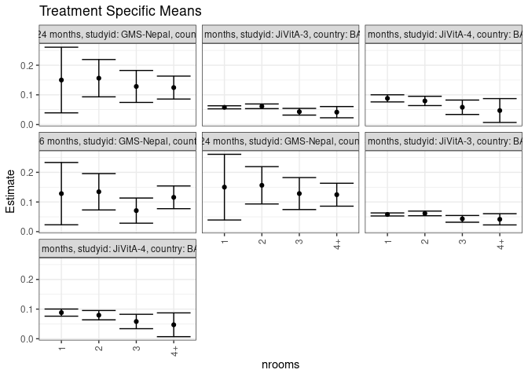

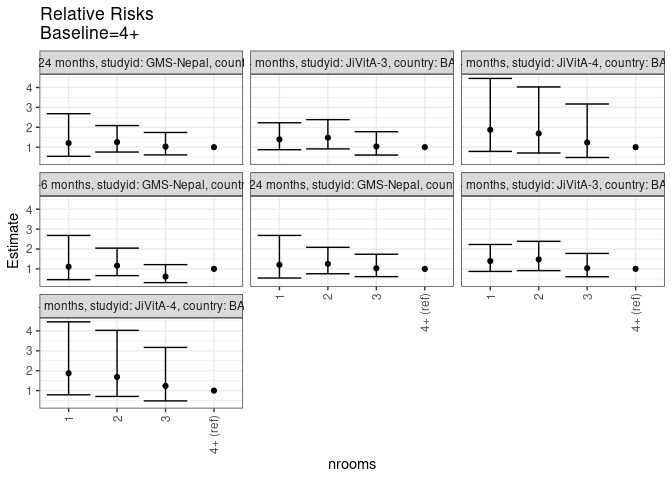

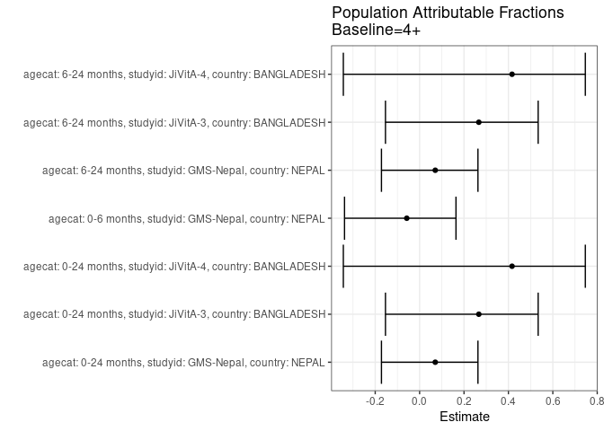

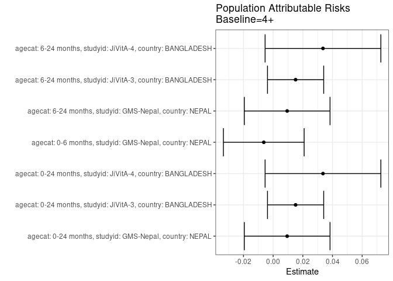

## Results Table

### Parameter: TSM

| agecat | studyid | country | intervention_level | baseline_level | estimate | ci_lower | ci_upper |
| --- | --- | --- | --- | --- | --- | --- | --- |
| 0-24 months | GMS-Nepal | NEPAL | 4+ | NA | 0.1245552 | 0.0859136 | 0.1631967 |
| 0-24 months | GMS-Nepal | NEPAL | 1 | NA | 0.1500000 | 0.0392517 | 0.2607483 |
| 0-24 months | GMS-Nepal | NEPAL | 2 | NA | 0.1562500 | 0.0932959 | 0.2192041 |
| 0-24 months | GMS-Nepal | NEPAL | 3 | NA | 0.1283784 | 0.0744408 | 0.1823159 |
| 0-24 months | JiVitA-3 | BANGLADESH | 4+ | NA | 0.0416048 | 0.0226740 | 0.0605355 |
| 0-24 months | JiVitA-3 | BANGLADESH | 1 | NA | 0.0579599 | 0.0528464 | 0.0630734 |
| 0-24 months | JiVitA-3 | BANGLADESH | 2 | NA | 0.0613956 | 0.0534872 | 0.0693039 |
| 0-24 months | JiVitA-3 | BANGLADESH | 3 | NA | 0.0430652 | 0.0317448 | 0.0543857 |
| 0-24 months | JiVitA-4 | BANGLADESH | 4+ | NA | 0.0471014 | 0.0069495 | 0.0872534 |
| 0-24 months | JiVitA-4 | BANGLADESH | 1 | NA | 0.0881880 | 0.0761297 | 0.1002462 |
| 0-24 months | JiVitA-4 | BANGLADESH | 2 | NA | 0.0794948 | 0.0638349 | 0.0951547 |
| 0-24 months | JiVitA-4 | BANGLADESH | 3 | NA | 0.0581818 | 0.0339166 | 0.0824471 |
| 0-6 months | GMS-Nepal | NEPAL | 4+ | NA | 0.1156716 | 0.0773465 | 0.1539968 |
| 0-6 months | GMS-Nepal | NEPAL | 1 | NA | 0.1282051 | 0.0231883 | 0.2332220 |
| 0-6 months | GMS-Nepal | NEPAL | 2 | NA | 0.1344538 | 0.0731073 | 0.1958002 |
| 0-6 months | GMS-Nepal | NEPAL | 3 | NA | 0.0709220 | 0.0285149 | 0.1133291 |
| 6-24 months | GMS-Nepal | NEPAL | 4+ | NA | 0.1245552 | 0.0859136 | 0.1631967 |
| 6-24 months | GMS-Nepal | NEPAL | 1 | NA | 0.1500000 | 0.0392517 | 0.2607483 |
| 6-24 months | GMS-Nepal | NEPAL | 2 | NA | 0.1562500 | 0.0932959 | 0.2192041 |
| 6-24 months | GMS-Nepal | NEPAL | 3 | NA | 0.1283784 | 0.0744408 | 0.1823159 |
| 6-24 months | JiVitA-3 | BANGLADESH | 4+ | NA | 0.0416048 | 0.0226740 | 0.0605355 |
| 6-24 months | JiVitA-3 | BANGLADESH | 1 | NA | 0.0579599 | 0.0528464 | 0.0630734 |
| 6-24 months | JiVitA-3 | BANGLADESH | 2 | NA | 0.0613956 | 0.0534872 | 0.0693039 |
| 6-24 months | JiVitA-3 | BANGLADESH | 3 | NA | 0.0430652 | 0.0317448 | 0.0543857 |
| 6-24 months | JiVitA-4 | BANGLADESH | 4+ | NA | 0.0471014 | 0.0069495 | 0.0872534 |
| 6-24 months | JiVitA-4 | BANGLADESH | 1 | NA | 0.0881880 | 0.0761297 | 0.1002462 |
| 6-24 months | JiVitA-4 | BANGLADESH | 2 | NA | 0.0794948 | 0.0638349 | 0.0951547 |
| 6-24 months | JiVitA-4 | BANGLADESH | 3 | NA | 0.0581818 | 0.0339166 | 0.0824471 |

### Parameter: E(Y)

| agecat | studyid | country | intervention_level | baseline_level | estimate | ci_lower | ci_upper |
| --- | --- | --- | --- | --- | --- | --- | --- |
| 0-24 months | GMS-Nepal | NEPAL | NA | NA | 0.1340034 | 0.1066544 | 0.1613523 |
| 0-24 months | JiVitA-3 | BANGLADESH | NA | NA | 0.0567340 | 0.0526176 | 0.0608504 |
| 0-24 months | JiVitA-4 | BANGLADESH | NA | NA | 0.0806971 | 0.0720842 | 0.0893100 |
| 0-6 months | GMS-Nepal | NEPAL | NA | NA | 0.1093474 | 0.0836377 | 0.1350572 |
| 6-24 months | GMS-Nepal | NEPAL | NA | NA | 0.1340034 | 0.1066544 | 0.1613523 |
| 6-24 months | JiVitA-3 | BANGLADESH | NA | NA | 0.0567340 | 0.0526176 | 0.0608504 |
| 6-24 months | JiVitA-4 | BANGLADESH | NA | NA | 0.0806971 | 0.0720842 | 0.0893100 |

### Parameter: RR

| agecat | studyid | country | intervention_level | baseline_level | estimate | ci_lower | ci_upper |
| --- | --- | --- | --- | --- | --- | --- | --- |
| 0-24 months | GMS-Nepal | NEPAL | 4+ | 4+ | 1.000000 | 1.0000000 | 1.000000 |
| 0-24 months | GMS-Nepal | NEPAL | 1 | 4+ | 1.204286 | 0.5406588 | 2.682476 |
| 0-24 months | GMS-Nepal | NEPAL | 2 | 4+ | 1.254464 | 0.7544253 | 2.085933 |
| 0-24 months | GMS-Nepal | NEPAL | 3 | 4+ | 1.030695 | 0.6113785 | 1.737602 |
| 0-24 months | JiVitA-3 | BANGLADESH | 4+ | 4+ | 1.000000 | 1.0000000 | 1.000000 |
| 0-24 months | JiVitA-3 | BANGLADESH | 1 | 4+ | 1.393108 | 0.8718977 | 2.225890 |
| 0-24 months | JiVitA-3 | BANGLADESH | 2 | 4+ | 1.475686 | 0.9130636 | 2.384992 |
| 0-24 months | JiVitA-3 | BANGLADESH | 3 | 4+ | 1.035104 | 0.6030048 | 1.776834 |
| 0-24 months | JiVitA-4 | BANGLADESH | 4+ | 4+ | 1.000000 | 1.0000000 | 1.000000 |
| 0-24 months | JiVitA-4 | BANGLADESH | 1 | 4+ | 1.872298 | 0.7868758 | 4.454961 |
| 0-24 months | JiVitA-4 | BANGLADESH | 2 | 4+ | 1.687736 | 0.7071931 | 4.027828 |
| 0-24 months | JiVitA-4 | BANGLADESH | 3 | 4+ | 1.235245 | 0.4813336 | 3.170004 |
| 0-6 months | GMS-Nepal | NEPAL | 4+ | 4+ | 1.000000 | 1.0000000 | 1.000000 |
| 0-6 months | GMS-Nepal | NEPAL | 1 | 4+ | 1.108354 | 0.4580729 | 2.681775 |
| 0-6 months | GMS-Nepal | NEPAL | 2 | 4+ | 1.162375 | 0.6613911 | 2.042838 |
| 0-6 months | GMS-Nepal | NEPAL | 3 | 4+ | 0.613132 | 0.3095066 | 1.214613 |
| 6-24 months | GMS-Nepal | NEPAL | 4+ | 4+ | 1.000000 | 1.0000000 | 1.000000 |
| 6-24 months | GMS-Nepal | NEPAL | 1 | 4+ | 1.204286 | 0.5406588 | 2.682476 |
| 6-24 months | GMS-Nepal | NEPAL | 2 | 4+ | 1.254464 | 0.7544253 | 2.085933 |
| 6-24 months | GMS-Nepal | NEPAL | 3 | 4+ | 1.030695 | 0.6113785 | 1.737602 |
| 6-24 months | JiVitA-3 | BANGLADESH | 4+ | 4+ | 1.000000 | 1.0000000 | 1.000000 |
| 6-24 months | JiVitA-3 | BANGLADESH | 1 | 4+ | 1.393108 | 0.8718977 | 2.225890 |
| 6-24 months | JiVitA-3 | BANGLADESH | 2 | 4+ | 1.475686 | 0.9130636 | 2.384992 |
| 6-24 months | JiVitA-3 | BANGLADESH | 3 | 4+ | 1.035104 | 0.6030048 | 1.776834 |
| 6-24 months | JiVitA-4 | BANGLADESH | 4+ | 4+ | 1.000000 | 1.0000000 | 1.000000 |
| 6-24 months | JiVitA-4 | BANGLADESH | 1 | 4+ | 1.872298 | 0.7868758 | 4.454961 |
| 6-24 months | JiVitA-4 | BANGLADESH | 2 | 4+ | 1.687736 | 0.7071931 | 4.027828 |
| 6-24 months | JiVitA-4 | BANGLADESH | 3 | 4+ | 1.235245 | 0.4813336 | 3.170004 |

### Parameter: PAR

| agecat | studyid | country | intervention_level | baseline_level | estimate | ci_lower | ci_upper |
| --- | --- | --- | --- | --- | --- | --- | --- |
| 0-24 months | GMS-Nepal | NEPAL | 4+ | NA | 0.0094482 | -0.0194569 | 0.0383533 |
| 0-24 months | JiVitA-3 | BANGLADESH | 4+ | NA | 0.0151292 | -0.0038199 | 0.0340784 |
| 0-24 months | JiVitA-4 | BANGLADESH | 4+ | NA | 0.0335957 | -0.0054292 | 0.0726205 |
| 0-6 months | GMS-Nepal | NEPAL | 4+ | NA | -0.0063242 | -0.0335510 | 0.0209026 |
| 6-24 months | GMS-Nepal | NEPAL | 4+ | NA | 0.0094482 | -0.0194569 | 0.0383533 |
| 6-24 months | JiVitA-3 | BANGLADESH | 4+ | NA | 0.0151292 | -0.0038199 | 0.0340784 |
| 6-24 months | JiVitA-4 | BANGLADESH | 4+ | NA | 0.0335957 | -0.0054292 | 0.0726205 |

### Parameter: PAF

| agecat | studyid | country | intervention_level | baseline_level | estimate | ci_lower | ci_upper |
| --- | --- | --- | --- | --- | --- | --- | --- |
| 0-24 months | GMS-Nepal | NEPAL | 4+ | NA | 0.0705071 | -0.1718485 | 0.2627400 |
| 0-24 months | JiVitA-3 | BANGLADESH | 4+ | NA | 0.2666698 | -0.1538143 | 0.5339170 |
| 0-24 months | JiVitA-4 | BANGLADESH | 4+ | NA | 0.4163180 | -0.3435495 | 0.7464293 |
| 0-6 months | GMS-Nepal | NEPAL | 4+ | NA | -0.0578358 | -0.3382265 | 0.1638063 |
| 6-24 months | GMS-Nepal | NEPAL | 4+ | NA | 0.0705071 | -0.1718485 | 0.2627400 |
| 6-24 months | JiVitA-3 | BANGLADESH | 4+ | NA | 0.2666698 | -0.1538143 | 0.5339170 |
| 6-24 months | JiVitA-4 | BANGLADESH | 4+ | NA | 0.4163180 | -0.3435495 | 0.7464293 |